# FE8828 Programming Web Applications in Finance

<sub>Week 2 Intermediate R Programming Shiny/2: R Web Framework Data Manipulation and EDA (Exploratory Data Analysis)/1</sub>

Dr. Yang Ye <sub><Email:yy@runchee.com></sub>

Nov 5, 2018

# Lecture 4: Intermediate R Programming

Let’s review some R basics and cover some intermediate R programming.

- Vector/Matrix/String/Date/Time
- Anonymous function
- List
- Environment
- Pipe
- Load/Save
- Data Frame

# R: Vector

Vector/Matrix/List/Dataframe

```r
# Create a vector from number
v <- c(1, 3)
v[1] <- 3
v
## [1] 3 3
```

```r
# repeat 100 for 10 times.
rep(100, 10)
##  [1] 100 100 100 100 100 100 100 100 100 100
```

# R: Matrix

```r
# create matrix of 10x10
mat <- matrix(2, 3, 4)
mat
##      [,1] [,2] [,3] [,4]
## [1,]    2    2    2    2
## [2,]    2    2    2    2
## [3,]    2    2    2    2
# set first row to 4
mat[1,] <- 4
# set element (2, 2) to 6
mat[2, 2] <- 6
```

# Find element in Vector

- `which()`
- `match()`
- `%in%`

```r
data <- 10:1
match(c(1, 3), data)
## [1] 10  8
data[match(c(1, 3), data)]
## [1] 1 3
which(1 == data | 3 == data)
## [1]  8 10
data[which(1 == data | 3 == data)]
## [1] 3 1
```

# Check whether element exists

- `FALSE` case when element doesn’t exist

```r
match(c(11, 31), 10:1)
## [1] NA NA
which(11 == 10:1 | 31 == 10:1)
## integer(0)
```

```r
if (all(c(1, 33) %in% 1:3)) {
  cat("Found all\n")
}

if (any(c(1, 33) %in% 1:3)) {
  cat("Found one/some.\n")
}
## Found one/some.
```

# Random

```r
# Norm random number
rnorm(3, mean = 10, sd = 3)
## [1] 7.704076 7.510235 9.450786
```

```r
# Uniform random number
runif(3)
## [1] 0.5398503 0.9412166 0.7695050
```

```r
# Sample
sample(1:10, 10, replace = FALSE)
##  [1]  5  3 10  9  1  4  2  6  7  8
# To Be/Not to Be
sample(c(T, F), 10, replace = TRUE)
##  [1]  TRUE FALSE  TRUE  TRUE FALSE  TRUE  TRUE  TRUE  TRUE FALSE
# Throw a dice
sample(1:6, 10, replace = TRUE)
##  [1] 5 2 2 2 6 3 3 3 5 6
```

# Print

- `cat(paste0(..., "\n"))` is what I used most.
- `"\n"` is appended to the end to create a line break.
- `paste0/paste` can use to create new strings from any data types.
- `paste0` combines any thing without space. `paste` uses space, by default.
- `paste0/paste` with `collapse` helps with vector to print them in one line.
- `paste0/paste` works with all types of data.

```r
x <- c(Sys.Date(), Sys.Date(), Sys.Date())
cat(paste0("Current dates is ", x, ".\n"))
## Current dates is 2018-11-21.
##  Current dates is 2018-11-21.
##  Current dates is 2018-11-21.
cat(paste0("Current dates is ", paste0(x, collapse = ", "), ".\n"))
## Current dates is 2018-11-21, 2018-11-21, 2018-11-21.
```

# String

```r
# sub-string
# substr(x, start, stop)
substr("The fox jumps.", 6, 6 + 5 - 1)
## [1] "ox ju"
```

```r
# paste0/paste to concatenate string/convert to string
new_string <- paste0("This is ", "cat")
new_string <- paste0("This is ", "cat", sep = "a")
new_string <- paste0(1:3, sep = "a")
```

```r
# toupper/tolower
toupper("big")
## [1] "BIG"
tolower("LOWER")
## [1] "lower"
```

# Find/Replace String in String

```r
# grepl: Find, returns T or F
grepl("A", "ABC", fixed = TRUE)
## [1] TRUE
grepl("D", "ABC", fixed = TRUE)
## [1] FALSE
```

```r
# sub: replace for one time
# sub(pattern, replace, string,...)
# fixed = TRUE means use fixed string. Not regular expression
sub("D", "ABC", "DDD", fixed = TRUE)
## [1] "ABCDD"
# gsub: replace for all
gsub("D", "ABC", "DDD", fixed = TRUE)
## [1] "ABCABCABC"
```

# Find/Replace String with Regular Expression (RE)

If you start to use regular expression, sub/grepl becomes super powerful.

```r
# If we need to find `Start` appearing the beginning of the string
grepl("^Start", "Start with me")
## [1] TRUE
grepl("^Start", "me Start")
## [1] FALSE
```

```r
# To find something in the end
sub("X$", "Z", "XYZ ends with X")
## [1] "XYZ ends with Z"
```

# Match/Extraction with Regular Expression (RE)

## Match (RE)

```r
sub("[^\\_]+\\_.*", "", "USDCNY_M1")
## [1] ""
```

- `[^\\_]`: Character not containing `_`. Because _ is a special character, we quote it with two backslashes.
- `+`: One or more
- `.`: Any character
- `*`: none or more.

# Match/Extraction with Regular Expression (RE)

## Extraction (RE)

```r
# Rough cut
sub("([^\\_]+)\\_.*", "\\1", "USDCNY_M1")
## [1] "USDCNY"
```

```r
# Nice cut
sub("([^\\_]+)\\_(.*)", "\\1 \\2", "USDCNY_M1")
## [1] "USDCNY M1"
```

```r
# Wonderful cut
sub("([^\\_]+)\\_([[:alpha:]])([[:digit:]])", "\\1 \\2 \\3", "USDCNY_M1")
## [1] "USDCNY M 1"
```

Cheatsheat is available at https://www.rstudio.com/resources/cheatsheets/

# Date

```r
# Create date
dt1 <- as.Date("2017-11-03")
dt1
## [1] "2017-11-03"
dt2 <- Sys.Date()
dt2
## [1] "2018-11-21"
```

```r
library(lubridate)
```

```r
# Date is such a central role in finance.
# More function about date can be found in package `lubridate`
# Create date with lubridate, a package which provides lots of date functions.
ymd(20171003)
## [1] "2017-10-03"
ymd("20171003")
## [1] "2017-10-03"
```

# Date: format code

We can use codes for convert date to/from string.

- %Y/%y: four-digit year/two-digit year
- %m: month in number
- %b/%B: month in abbreviation/full, i.e. Jan/January.
- %d: day

```r
format(Sys.Date(), format = "%Y/%m/%d")
## [1] "2018/11/21"
```

```r
as.Date("2017-11-03", format = "%Y-%m-%d") # %m for number month
## [1] "2017-11-03"
as.Date("2017-Nov-03", format = "%Y-%b-%d") # %b for the 3-letter month
## [1] "2017-11-03"
as.Date("03Nov2017", format = "%d%b%Y")
## [1] "2017-11-03"
```

# Other functions from `lubridate`

```r
library(lubridate)
# Change a date
x <- as.Date("2017-10-10")
month(x) <- 1
x
## [1] "2017-01-10"
```

```r
# Set to the end of the month
day(x) <- days_in_month(x)
```

# Business days

Use package `bizdays`

```r
# install.packages("bizdays")
library(bizdays)
```

```r
# 'weekends' is a calendar of weekdays
bizdays("2017-10-16", "2017-10-30", "weekends")
## [1] 10

# add bizdays
add.bizdays("2017-11-03", 5, "weekends")
## [1] "2017-11-10"

# generate all business days between two dates.
# You will find this useful for financial application.
bizseq("2017-11-10", "2017-12-01", "weekends")
##  [1] "2017-11-10" "2017-11-13" "2017-11-14" "2017-11-15" "2017-11-16"
##  [6] "2017-11-17" "2017-11-20" "2017-11-21" "2017-11-22" "2017-11-23"
## [11] "2017-11-24" "2017-11-27" "2017-11-28" "2017-11-29" "2017-11-30"
## [16] "2017-12-01"
```

# Calendar

If not provided, start.date is by default the first holiday and end.date is the last holiday. So we provide them here.

```r
create.calendar(name="Singapore", holidays = c(as.Date("2017-10-18")),
                start.date = as.Date("2017-01-01"), end.date = as.Date("2071-01-01"),
                weekdays = c("saturday", "sunday"))

bizdays("2017-10-13", "2017-10-30", "weekends")
## [1] 11
# One day less
bizdays("2017-10-13", "2017-10-30", "Singapore")
## [1] 10
```

# Functions

Input parameters

```r
func1 <- function() { }

func2 <- function(input1, input2) { }

# Param input1 is default to 1
func3 <- function(input1 = 1, input2) { }

func4 <- function(input1, input_type = c("int", "char"))
{
  # This would check whether input_type is set to one of the pre-set values.
  input_type = match.arg(input_type)
}

func5 <- function(in1, in2) {
  if (in1 < 0) {
    return(0)
  } else {
    return(in1 + in2)
  }
}
```

# Functions

```r
# The last value before function finishes will be returned automatically. No need to use return.
func5 <- function(in1, in2) {
  if (in1 < 0) {
    0
  } else {
    in1 + in2
  }
}

# Unless there is extra steps before
func6 <- function(in1, in2) {
  if (in1 < 0) {
    return(0) # if we have 0 here, it's not the last step before function exits.
  } else {
    res <- in1 + in2
  }

  res <- res * 3
  res
}
```

# Exercise

Write functions to do

- Determine leap year?
- Print the list of month names in abbreviation or full
- Write a function to count how many working days in a year, given 1) the year 2) list of holidays?

# Time

Convert time to character/string

- %H: hour
- %M: minute
- %S: second

```r
format(Sys.time(), format = "%H%M")
## [1] "1148"
format(Sys.time(), format = "%H:%M:%S")
## [1] "11:48:03"
format(Sys.time(), format = "%H:%M:%S")
## [1] "11:48:03"
library(lubridate)
ymd_hms("2011-12-31 12:59:59")
## [1] "2011-12-31 12:59:59 UTC"
```

# Time

Change time, lubridate provides `hour`, `minute`

```r
x <- Sys.time()
x
## [1] "2018-11-21 11:48:03 +08"
hour(x) <- 12
x
## [1] "2018-11-21 12:48:03 +08"
minute(x) <- 3
x
## [1] "2018-11-21 12:03:03 +08"
minute(x) <- 123 # what will happen?
x
## [1] "2018-11-21 14:03:03 +08"
```

# List

```r
# Create a list with list() function
# Nameless list
# list[_n_] => item by order
a <- list(3, 4)
a[[1]]
## [1] 3
a[[2]]
## [1] 4

# Named list, you can use $ and [ operators
# list[[]]: gives back a value
# list$name => list[["name"]]
a <- list(a = 3, b = 4)
a[[1]]
## [1] 3
a[[2]]
## [1] 4
a[["a"]]
## [1] 3
a$a
## [1] 3
```

# List

```r
# When you want to use a number as key, use backtick
list_of_strikes <- list()
list_of_strikes$`65` <- 3
list_of_strikes$`60` <- 4

# if a name doesn't exist in the list
a$c
## NULL
# Use `is.null()` to check
if (is.null(a$c)) {
  cat("c doesn't exist in list a\n")
}
## c doesn't exist in list a
```

# List

```r
list <- list(elem = 1, c1 = "a", c2 = "b")

# access the list
list[[1]]
list$elem
```

```r
# add new member to the list
list$new_elem <- 3
# update member in the list
list$c1 <- 3

# Delete c1 in the list
list$c1 <- NULL

list
## $elem
## [1] 1
##
## $c2
## [1] "b"
##
## $new_elem
## [1] 3
```

# List’s Usage - 1

```r
# List can be used as map/dictionary.
# Map
basket <- sample(c("Apple", "Orange", "Pear"), 100, replace = TRUE)
fruit_count <- list()
for (b in basket) {
  if (is.null(fruit_count[[b]])) {
    fruit_count[[b]] <- 1
  } else {
    fruit_count[[b]] <- fruit_count[[b]] + 1
  }
}
fruit_count
## $Apple
## [1] 42
##
## $Pear
## [1] 27
##
## $Orange
## [1] 31
```

# List’s Usage - 2

```r
# Let's write a generic function to do this
add_to_map <- function(map, key, value) {
  if (is.null(map[[key]])) {
    map[[key]] <- value
  } else {
    map[[key]] <- map[[key]] + value
  }
  map
}

# You may copy function add_to_map to every file that you want to use this kind of dictionary
fruit_count <- add_to_map(fruit_count, "Pomelo", 12)
fruit_count
## $Apple
## [1] 42
##
## $Pear
## [1] 27
##
## $Orange
## [1] 31
##
## $Pomelo
## [1] 12
```

# List’s Usage

```r
# Use case 1: Use list to pass data in or out.
do_lots_of_work <- function(a, b, c) {
}
# pass in
do_lots_of_work <- function(lst) {
  lst$a + lst$b
}
# pass out
ret_lots_of_work <- function() {
  return(list(a = a, b = b))
}

res <- ret_lots_of_work()
res$a
## $a
## [1] 3
##
## $b
## [1] 4
res$b
## [1] "Pear"
```

```r
# Case 2: configuration
app_config <- list(MAX = 10, MIN = 10, DISPLAY_RESULT = TRUE)

do_lots_of_work <- function(app_config) {
  app_config$MAX
}
```

# Object

```r
# Object
# Define class with attributes.
vanilla_option <- setClass("vanilla_option",
                           slots = c(type = "character",
                                     strike = "numeric",
                                     underlying = "numeric"))
# Create object, either way
opt1 <- new("vanilla_option", type = "c", strike = 100, underlying = 100)
opt2 <- vanilla_option(type = "c", strike = 100, underlying = 100)

# Use @ to visit member. or,
opt1@type
## [1] "c"
slot(opt1, "strike")
## [1] 100
```

# Work with objects

```r
# Generate a vector of options
opts <- sapply(1:10000, function(x) {
                       vanilla_option(type = sample(c("c", "p"), 1),
                                      strike = round(runif(1) * 100, 0),
                                      underlying = round(runif(1) * 100, 0)) } )

# install.packages("fOptions")
library(fOptions)

start <- Sys.time()
# GBSOption also returns an object. We just need its price attribute.
res1 <- sapply(opts, function(o) {
  (GBSOption(o@type, o@underlying, o@strike, Time = 1,
             r = 0.01, b = 0, sigma = 0.3))@price
})
cat(as.numeric(Sys.time() - start))
## 1.671597
head(res1, n = 4)
## [1] 8.019404e+01 6.633335e+01 2.959301e-08 3.403163e+00

# Alternatively to sapply, we can use map* functions from purrr package
# map is a generic function that returns a list
# map_dbl is for result of double, it would return a vector
library(purrr)

res2 <- purrr::map_dbl(opts, function(o) {
  (GBSOption(o@type, o@underlying, o@strike, Time = 1,
             r = 0.01, b = 0, sigma = 0.3))@price
})
head(res2, n = 4)
## [1] 8.019404e+01 6.633335e+01 2.959301e-08 3.403163e+00
```

# Anonymous Function

```r
# Function that's defined in-place, which doesnt' need to have a name.
(function(x) { print(x) }) (3)
## [1] 3
# if there is only one line, you can skip { }
(function(x) print(x)) (3)
## [1] 3

# For longer functions, you can make it multi-lines.
(function(x) {
  if (x > 3) {
    print(x)
  } else {
    print(x - 3)
  }
})(3)
## [1] 0
```

# purrr::map and sapply Function

```r
library(purrr) # install.packages("purrr")

# These two are equivalent.
res1 <- purrr::map(1:10, function(x) { rnorm(x, n = 10) })
# function(x) func(x) can be simplied as func.
res2 <- purrr::map(1:10, rnorm, n = 10)
head(res1, n = 1)
## [[1]]
##  [1]  0.2439474  2.2634302  2.4025574  1.9769947 -0.8155511  2.3661138
##  [7]  0.3501966  1.6482255 -0.2068518  0.2687588
# purrr:map returns a list()
```

```r
# This is what we really want to do. Generate ten normal distribution and get their mean.
# rnorm(n, mean = 0, sd = 1). Where does the input go to?
res <- purrr::map(1:10, rnorm, n = 1000)
map_dbl(res, mean)
##  [1]  1.015527  2.025985  3.000414  4.059144  5.052160  6.024167  6.978853
##  [8]  7.994170  9.053392 10.059195

# sapply achieves the same as purrr::map, a bit slower.
# Package purrr succeeds original R base.
sapply(1:10, function(x) x ^ 2 )
##  [1]   1   4   9  16  25  36  49  64  81 100
sapply(1:10, function(x) `^` (x, 2) )
##  [1]   1   4   9  16  25  36  49  64  81 100
sapply(1:10, function(x) `^` (2, x) )
##  [1]    2    4    8   16   32   64  128  256  512 1024
```

# Read/Write data

```r
# set working directory
setwd("C:/TEMP")
# Save this_is_var1 to a file
saveRDS(this_is_var1, file = "C:/TEMP/DATA/data.Rds")
# Load a variable from a file. `new_loaded` is the name given to it.
new_loaded <- readRDS(file = "C:/TEMP/DATA/data.Rds")
```

- On Windows, use double slashes `\\` or single backslash `/`. e.g. `C:\\TEMP\\DATA`, `C:/TEMP/DATA`
- On Mac, use backslash `/Users/.../`

# R: data frame

The basic structure of a data frame:

- There is one observation per row and
- Each column represents a variable, a measure, feature, or characteristic of that observation.
- In summary, **2D table**

```r
df <- data_frame(
  date = seq(as.Date("2017-01-01"), as.Date("2017-01-10"), by = "day"),
  stock = replicate(10, paste0(sample(LETTERS, 3, replace = TRUE), collapse = "")),
  quantity = round(runif(10) * 10000 ,0))
# df["date"]: gives a data frame
# df[["date"]]: gives value
# df$date: same as [["date"]]

# Get three rows
df[c(3, 6, 9), , drop = F]
```

```r
# Get three columns
df[, 1, drop = F]
# This would return a vector
df[, 1, drop = T]

# Use column names
df[, c("date", "quantity"), drop = F]
```

# R: data frame

Common functions for data frame

```r
View()
head()
tail()
str()
nrow()
ncol()
dim() # returns both nrow and ncol
colnames()/rownames()
```

# Birthday Problem

- With different weights to the month
- N simulation

```
## [1] 15
## [1] 108
## [1] 37.725
```

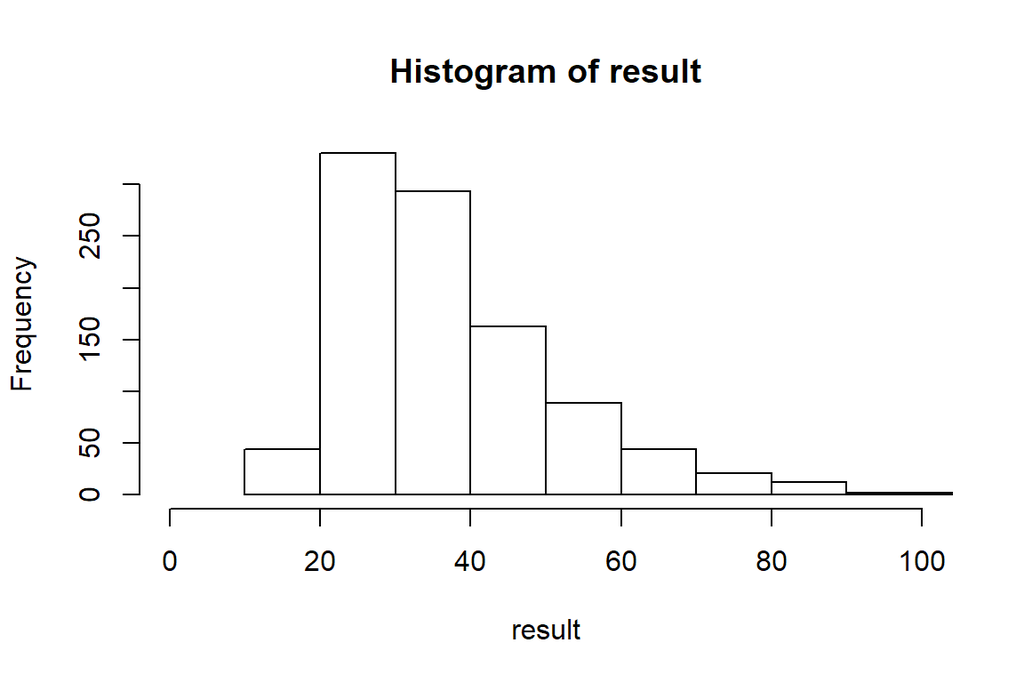

# Fastest Fish Problem

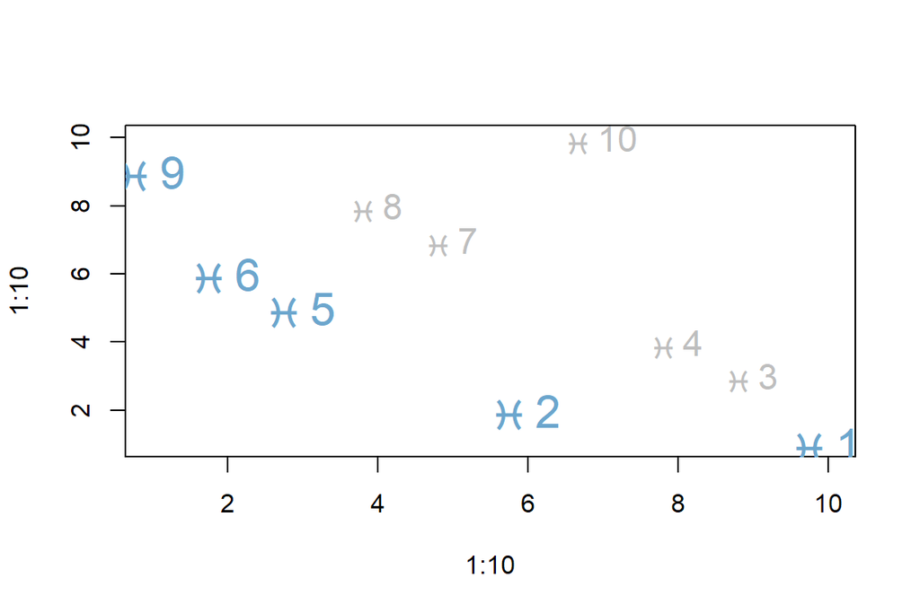

```
## res_sim: 2.9182
## res_ana: 2.92896825396825
```

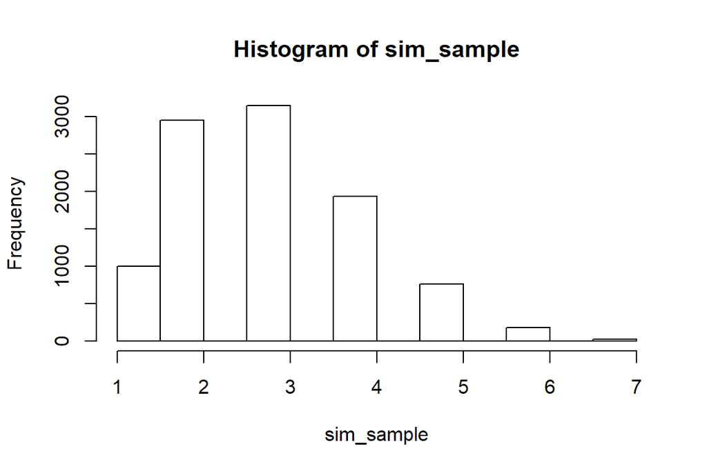

# How long to make a choice?

Step 1: make_choice <- function(N, split_number)

1. Generate a list `input_list` of `N` long with integer 1 to N at random position
2. Split the list `input_list` into two: evaluation group and selection group.
3. Remember the best number from evaluaton group and match the first number in selection group, >= than best.
4. Returns this number

Run this function for a few (hundred) times and find the probability of getting N

Step 2: find_optimal, calls Step 1 a few (hundred) times for each of the split number from 1 to N/2. So we can find the optimal value for the split for the N.

Answer: I suggest to find the solution for N = 3, and N = 10, then move straight on to N = 100.

# Lecture 5: Shiny/2: R Web Framework

# Minimalist

```r
library(shiny)
ui <- fluidPage("Hello World")
server <- function(input, output, session) { }
shinyApp(ui = ui, server = server)
```

# Think around Input and Outputs

```r
ui <- fluidPage(
  titlePanel("Hello World with a Histogram"),
  # Input() functions
  numericInput("num", "Number of Sample", value = 30),
  # Output() functions
  plotOutput("hist")
)
```

# Input

All input function follow such function signature except for input-specific parameters.

```r
inputXXX(inputId = "input name", label = "label to display", ...)
```

- `numericInput`
- `textInput`
- `passwordInput`
- `slideInput`
- `selectInput`
- `dateInput`

Reference: https://shiny.rstudio.com/reference/shiny/1.1.0/

# Output

All output functions follow such pattern.

```r
yyyOutput(outputId = "output name")
```

- `textOutput("text")`
- `verbatimTextOutput("text_orignal")`
- `tableOutput("t1")`
- `dataTableOutput("t2")`
- `plotOutput(outputId = "hist", width = "400px", height = "400px")`
- `uiOutput("uiX")`

For plotOutput, I suggest to set width and height to fixed size so we need extra parameters. For other kinds of outputs, only `outputId` is good enough.

# Server

Sever is to fill the content of output

```r
server <- function(input, output, session) {
  # Enable either one of two
  output$hist <- renderPlot({ hist(rnorm(100)) })

  if (FALSE) {
    output$hist <- renderPlot({
      title("a normal random number histogram")
      hist(rnorm(input$num))
    })
  }
}
```

## shinyApp = UI + Server

- UI and Server combine to be a ShinyApp.
- UI is to run the same for each browser/client.
- Server is separate between different users.

```r
shinyApp(ui, server)
```

# Reactivity Kicks In

- Reactivity: `input$num ------> output$p1`
- Reactivity links input to the output like a data flow.

Reactive values work together with reactive functions.

1. Reactive function responds. `input$x => output$y`
2. Reactive value notifies. `input$x => expression() => output$y`

# Reactivity - 1

Reactivity is enabled by placing input `inputXXX` inside `renderXXX` function. (shiny-21.R)

```
library(shiny)

ui <- fluidPage(
  numericInput("num", "Num", 100),
  # numericInput("mean", "Mean", 5),
  # numericInput("sd", "SD", 3),
  numericInput("lambda", "Lambda", 1),
  plotOutput("p1")
)

server <- function(input, output, session) {
  output$p1 <- renderPlot({
    # hist(rnorm(input$num, mean = input$mean, sd = input$sd))
    hist(rpois(n = input$num, lambda = input$lambda))
  })
}

shinyApp(ui, server)
```

# Reactivity - 2

- Button represents a manual trigger of the action.
- We use `observeEvent` to observe button action, and `isolate` to cut down the link of `inputXXX` in `renderXXX`, so button can work.
- If we remove `isolate`? (shiny-22.R)

```
library(shiny)

ui <- fluidPage(
  numericInput("num", "Num", 10),
  actionButton("go", "Go"),
  plotOutput("p1")
)

server <- function(input, output, session) {
  observeEvent(input$go, {
    output$p1 <- renderPlot({
      # hist(rnorm(isolate(input$num)))
      # To make code in good clarity, I re-write above one line into below two lines
      # with additional variable input_num to hold the value from input$num.
      input_num <- isolate(input$num)
      hist(rnorm(input_num))
    })
  })
}

shinyApp(ui, server)
```

# Reactivity - 3

We can add a reactiveValue with `eventReactive`. (shiny-23.R)

```
library(shiny)

ui <- fluidPage(
  numericInput("num", "Num", 10),
  actionButton("go", "Go"),
  plotOutput("p1")
)

server <- function(input, output, session) {
  data <- eventReactive(input$go, {
    hist(rnorm(input$num))
  })
  # Variable data becomes a reactive variable.
  # What changes to it will trigger the output.
  output$p1 <- renderPlot({ data() })
}

shinyApp(ui, server)
```

# Output

For tableOutput

```r
output$t1 <- renderTable(iris)

output$t1 <- renderTable({
  some input..
  output is a data frame.
})
```

For dataTableOutput (Dynamic table)

```r
output$t2 <- renderDataTable(iris)
```

For plotOutput

```r
output$p2 <- renderPlot({ plot(runif(1000), runif(1000)) })
```

For textOutput and verbatimTextOutput

```r
output$t3 <-  renderText({ "foo" })
output$t4 <- renderPrint({
  print("foo")
  print("bar")
})
```

# Example: (Shiny-24.R)

```
library(shiny)
library(DT)

ui <- fluidPage(
  h3("t1"),
  tableOutput("t1"),
  hr(),
  fluidRow(
    column(9, h3("dt1"),
           dataTableOutput("dt1")),
    column(3,   h3("x4"),
           verbatimTextOutput("x4"))),
  hr(),
  fluidRow(
    column(8, h3("dt2"),
           dataTableOutput("dt2")),
    column(4, h3("p5"),
              plotOutput("p5")))
)

options(error = function() traceback(2))

server <- function(input, output, session) {
  output$t1 <- renderTable(iris[1:10,], striped = TRUE, hover = TRUE)
  output$dt1 <- renderDataTable(iris, options = list( pageLength = 5))
  output$x4 <- renderPrint({
      s = input$dt1_rows_selected
      if (length(s)) {
        cat('These rows were selected:\n\n')
        cat(s, sep = ', ')
      }
    })

  output$dt2 <- renderDataTable(iris,
                                options = list(pageLength = 5),
                                server = FALSE)
  output$p5 <- renderPlot({
    s <- input$dt2_rows_selected
    plot(iris$Sepal.Length, iris$Sepal.Width)
    if (length(s)) {
      points(iris[s, c("Sepal.Length", "Sepal.Width"), drop = F],
             pch = 19, cex = 1, col = "red")
    }
  })
}

shinyApp(ui, server)
```

# Debug Shiny

- Debug in R Studio
- Clear all variable to run Shiny in R Studio
- debugSource, if you use other source code

# Shiny Summary

- Reactive is about wiring input and output
- Connect from receiver: plot/tabulate for data
- Connect from trigger: button, isolate to create a Chinese wall

# Shiny Assignment

1. For Shiny-24.R, add a selectInput for different color names, returned from `colors()`.

```r
plot(1:10, pch = 19, cex = 1, col = "skyblue1")
```

2. Create a Bond Schedule
- Inputs: start date, tenor, coupon rate, coupon frequency, and yield to maturity.
- Output: coupon schedule (ignore public holidays), amount in table and plot. NPV

$NPV = \frac{Cashflow 1}{(1 + yield)^1} + \frac{Cashflow 2}{(1 + yield)^2} + ... + \frac{Last Cashflow}{(1 + yield)^n}$

For a Bond with fixed coupon $Bond Price = Coupon * \frac{1 - (\frac{1}{(1 + yield)^n})}{yield} + \Big[MaturityValue * \frac{1}{(1 + yield)^n}\Big]$

# Lecture 6: Data Manipulation and EDA (Exploratory Data Analysis)/1

# Tidyverse

install.packages(“tidyverse”)

[figure not shown]

# SQL

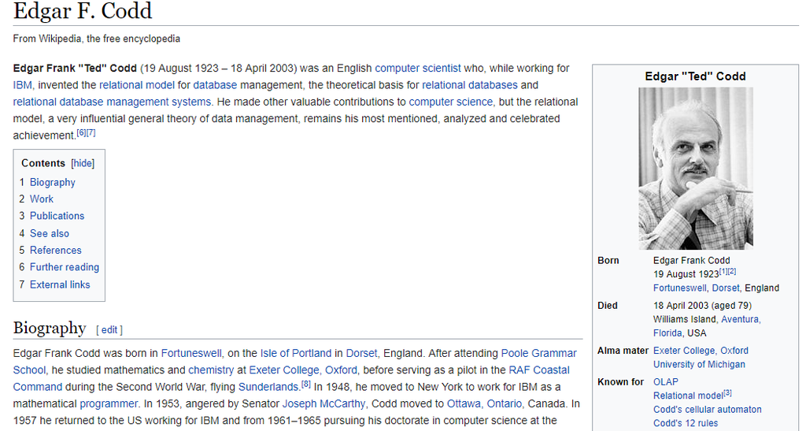

# CRUD: Create | Read | Update | Delete

Data engineering was born around 70s with SQL.

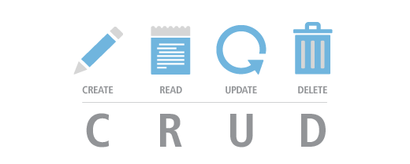

# SQL does CRUD

```sql
# Select everything from Shops.
SELECT * FROM Shops;

# Select with a filter
SELECT * FROM Shops WHERE size = "Big";

# Select with a filter and order
SELECT * FROM Shops WHERE size = "Big" ORDER BY Name;

# Select with a filter, order, group and summary function `sum`
SELECT Region, sum(Sales) FROM Shops WHERE size = "Medium" GROUP BY Region;

# Insert a new record to Shops.
INSERT into Shops (Name, Region, Sales) VALUES ("Costco", "North", 123456, ...);

# Update a field
UPDATE Shops SET Sales = Sales + 1000 WHERE Name = "Costco";

# Delete from Shops with a filter
DELETE from Shops WHERE Sales < 1000
```

# Data frame does CRUD

```r
df <- data.frame(a = 1:10, b = 10:1)
# Select (aka Filter)
df[which(df$a == 3 | df$b == 3), , drop = T]
df[match(3, df$a), , drop = T]
df[, match("b", colnames(df)), drop = T]

# Insert
rbind(df, df)

# Delete
df[-(which(df$a == 3 | df$b == 3)), , drop = T]

# Update
df[which(df$a == 3 | df$b == 3), 2] <- 3
```

# dplyr

dplyr package from tidyverse is a high-performance package to deal data in data frame.

```r
# tidyverse is a bundle of packages.
# I usually load them all with library(tidyverse, instead of library(dplyr) individually.
library(tidyverse)
# Loading tidyverse: ggplot2
# Loading tidyverse: tibble
# Loading tidyverse: tidyr
# Loading tidyverse: readr
# Loading tidyverse: purrr
# Loading tidyverse: dplyr

# Note:
# filter(): dplyr, stats
# lag():    dplyr, stats
# Use dplyr::lag and dplyr::filter when it doesn't work.
```

# How dplyr works

`dplyr` provides functions in “verbs”, which is functions that does one thing only. We will learn to use the following.

# Sample dataset

## A data-driven approach to predict the success of

telemarketing

#### http://dx.doi.org/10.1016/j.dss.2014.03.001

I chose this data set of a Portuguese retail bank clients profile

[figure not shown]

# Sample dataset columns

variable = column = field

### Personal profile

- 1 - age (numeric)
- 2 - job : type of job (categorical: “admin.”,“unknown”,“unemployed”,“management”,“housemaid”,“entrepreneur”,“student”, “blue-collar”,“self-employed”,“retired”,“technician”,“services”)
- 3 - marital : marital status (categorical: “married”,“divorced”,“single”; note: “divorced” means divorced or widowed)
- 4 - education (categorical: “unknown”,“secondary”,“primary”,“tertiary”)
- 5 - default: has credit in default? (binary: “yes”,“no”)
- 6 - balance: average yearly balance, in euros (numeric)
- 7 - housing: has housing loan? (binary: “yes”,“no”)
- 8 - loan: has personal loan? (binary: “yes”,“no”)

### Related with the last contact of the current campaign:

- 9 - contact: contact communication type (categorical: “unknown”,“telephone”,“cellular”)
- 10 - day: last contact day of the month (numeric)
- 11 - month: last contact month of year (categorical: “jan”, “feb”, “mar”, …, “nov”, “dec”)
- 12 - duration: last contact duration, in seconds (numeric)

### Other attributes:

- 13 - campaign: number of contacts performed during this campaign and for this client (numeric, includes last contact)
- 14 - pdays: number of days that passed by after the client was last contacted from a previous campaign (numeric, -1 means client was not previously contacted)
- 15 - previous: number of contacts performed before this campaign and for this client (numeric)
- 16 - poutcome: outcome of the previous marketing campaign (categorical: “unknown”,“other”,“failure”,“success”)

### Output variable (desired target):

- 17 - y - has the client subscribed a term deposit? (binary: “yes”,“no”)